# Practical Machine Learning

Johan Kullingsjö

Friday, April 24, 2015

## Background

Six people have performed barbell lifts correctly and incorrectly in 5 different ways. About 160 features have been derived (including some metadata). We want to explore the dataset and try to predict how a person perform. To our help we have around 19000 classified records.

### Strategy

1. Look through the variables
- Type of variables (Quantative, Qualitative …)
- Distribution
- Missing Values
2. Make a Principal Component Analysis
- First on raw variables
- Then on transformed
3. Look for outliers
- Remove outliers (whole records) from analysis  
  *Later, look at them separately*
4. Decide on strategy (ML-method)
- Before looking at data we might do some guesses.
  - Five different behaviours (A, B, C, D, E)
  - Six subjects pedro, adelmo, carlitos, charles, eurico, jeremy

  We can suspect to both see clustering for subjects and behaviour  
  It’s likely to see some extreme values that can be seen as measure artefacts

  We have almost 20 000 examples, but only six subjects  
  This means that if the suspicion is correct that the  
  subjects differ substantially from each other in a PCA  
  we will have difficulties to make a general model that would predict  
  well for new subjects.

  To decide a final machinelearning algorithm is an iterative process so  
  where we finally ends depends on the performance on the different approaches we test.

  How general should our model be?  
  In this particular case it seems that our test data concists of data from same subjects as we have in our train data. If we don’t  
  need to predict from data collected from an unknown person we should be  
  able to get pretty decent predictions.

  Two models worth trying are
  - PCA and KNN (one model for each subject)
  - Random forrest like model

  Both models will probably perform well on subjects in training data  
  But generalize very poorly to subjects not included in the model. (Random forrest probably a bit better since it will likely find data from the subject most alike todo predictions, but still poor). Another benefit from random forrest is that one model is enough and you don’t need  
  the name/identifier of each person.

  If we on the other hand wants to make a model that generalize well to new subjects we need something different. Since we have so few subjects it will be hard to know how well our model generalize to new persons ( because we don’t know how well our subjects describe the space of all body shapes )  
  Some metadata (height, weight, gender, age …) would help (but that we don’t have)

  Two models worth trying are
  - PCA and KNN (one model for each behaviour) , Measure distance to model
  - Models that separates one behaviour from all others (create at least one model foreach behaviour) (something like SVM )

  If we are lucky these generalize well (though hard to know with only six subjects )  
  (and might be similar on both in sample and out of sample predictions compared to the less general model)
5. Since the limitation is 5 plots I will only show the principal ideas and the end results in the plots.

## The analysis

LOAD LIBRARIES

```r
  # Load libraries
  # caret
  library(dplyr)
  library(tidyr)
  library(pcaMethods)
```

Define functions for performing the suggested ML methods

```r
# my own KNN (change to other if time ...)
knn <- function(scores_orig, scores_pred, orig_data, k=10) {
  # predict behaviour class (classe column)

  dist <- apply(scores_orig, 1, FUN = (function(x) {sqrt(sum((scores_pred-x)**2))}))

  # rank the distvector
  # extract indices with rank <= k
  ind <- which(rank(dist)<=k)
  #print(ind)

  # select classe for those indices from orig data
  my_class <- orig_data[ind,] %>%
    select(classe)
  # look at distribution, choose class with highest density
  m <- data.frame(table(my_class))

  m <- m %>%
    tbl_df %>%
    arrange(desc(Freq))

  print(m)
  prediction <- m$my_class[1][[1]]

  return(as.character(prediction))

  # Todo as improvements
  # if equal, remove one until one is highest ...

  # we can also look at prior probabillities ... better do in other fct and ret table
  # from here

}


predict_multi <- function(data2predict_t, data2createModel, user, Pcs=6 , k=10) {
    # predict behaviour for multiple records
    model_data <- filter(data2createModel, outlier1!="strong",  user_name==user)
    res_pca <- pca(model_data, scale = "uv", center = TRUE,nPcs = Pcs)
#
    my_load <- loadings(res_pca)
    varnames <- row.names(my_load)

    pred_data <-  data2predict_t[,varnames] #use these for prediction

  res_pred <- predict(object = res_pca,
        newdata = pred_data,
        pcs = nP(res_pca),
        pre = TRUE,
        post = FALSE)

  apply(res_pred$scores,MARGIN = 1, FUN = (function(x) {
    x <- matrix(x, nrow = 1,dimnames = list(1,names(x)))
    knn(scores_orig=scores(res_pca), scores_pred=x, orig_data=model_data, k=k)
  }))
}
```

Load data

```r
# load data, cache the result
train <- read.csv("pml-training.csv")
test <- read.csv("pml-testing.csv")
train <- tbl_df(train)
test <- tbl_df(test)
```

*Variable selection* As a first selection on variables I check for missing values and only keep measures that have few missing values and the metadata (identification, timestamp, behaviourclass …). To look at the code, search for chunck name variable_selection  
In total 60 variables (including 7 meta variables) are kept

*PCA overall*  
Principal Component Analysis, color on subjects. We have a clear separation between all subjects (except overlap in one case)  
When investigating higher components we discover one record is a severe outlier (Outlier can be identified with X = “5373”, search code chunk pca_overall for code)  
We therefore add a column “outlier” to our dataset. This will be used to exclude this observation when we create our training models later on.

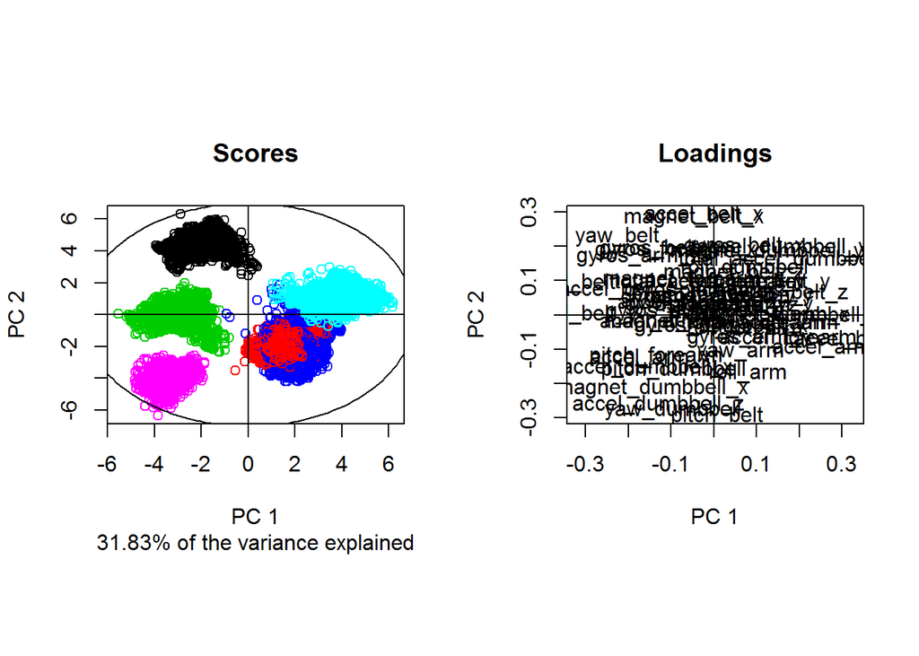

PCA for subject Pedro,  
color by behaviour class (classe)

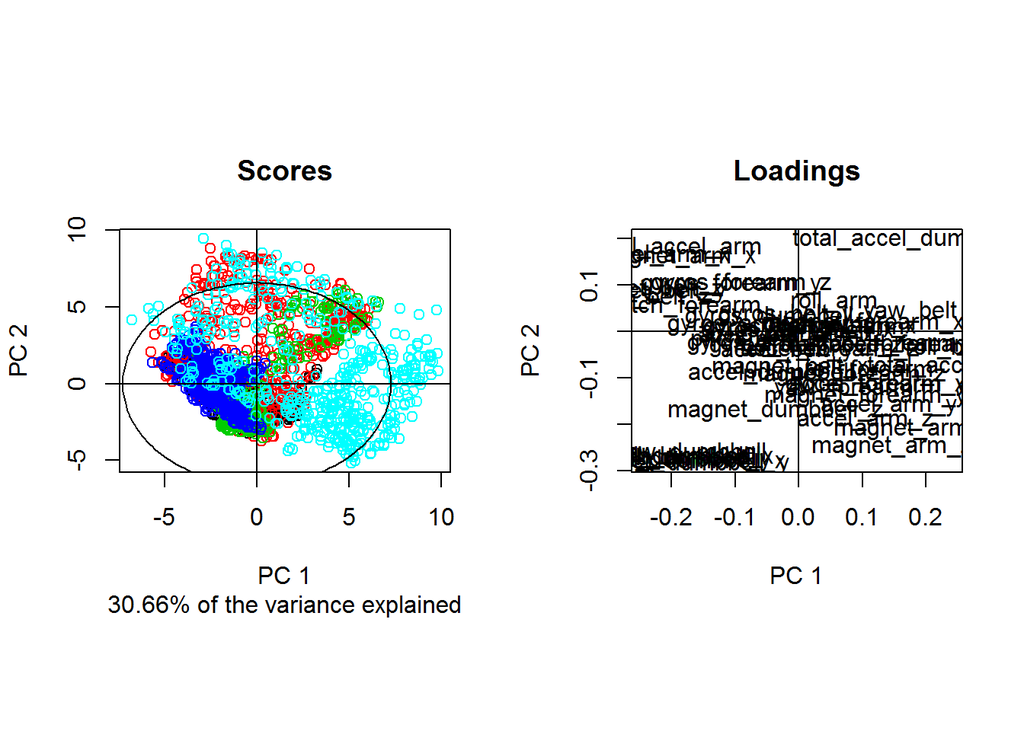